# Beech Marcenscence Project Analysis

## 3.7 Fungal count

**key takeaways**: Only time of year affected fungal count.

### 3.7.1 Model

```r
fg.m1 <- glmmTMB(
   fungal.count~
    treatment +
    dom_log.scale +
    leaf_area_mm2_log.scale +
    exp.round +
    (1|tree)  +
    ar1(0 + exp.round | tree),
  family = nbinom2(link = "log"),
  data = d
); summary(fg.m1)
```

```
 Family: nbinom2  ( log )
Formula:
fungal.count ~ treatment + dom_log.scale + leaf_area_mm2_log.scale +
    exp.round + (1 | tree) + ar1(0 + exp.round | tree)
Data: d

     AIC      BIC   logLik deviance df.resid
  1541.1   1584.5   -760.5   1521.1      562

Random effects:

Conditional model:
 Groups Name        Variance Std.Dev. Corr
 tree   (Intercept) 0.7991   0.8939
 tree.1 exp.round1  0.9795   0.9897   -0.54 (ar1)
Number of obs: 572, groups:  tree, 65

Dispersion parameter for nbinom2 family (): 0.834

Conditional model:
                        Estimate Std. Error z value Pr(>|z|)
(Intercept)             -6.03646    1.18772  -5.082 3.73e-07 ***
treatmenttreatment      -0.09365    0.32269  -0.290 0.771666
dom_log.scale           -0.22063    0.35992  -0.613 0.539869
leaf_area_mm2_log.scale -0.02381    0.11372  -0.209 0.834160
exp.round2               4.49458    1.24664   3.605 0.000312 ***
exp.round3               7.99953    1.25962   6.351 2.14e-10 ***
---
Signif. codes:  0 '***' 0.001 '**' 0.01 '*' 0.05 '.' 0.1 ' ' 1
```

### 3.7.2 Diagnostics

**So the diagnostics don’t look that great. The quasi-Poisson distribution seems to be a better choice as the conditional distribution (yielding no issue in the diagnostics), but since the results don’t change qualitatively, we will only consider the type II negative binomial model for the sake of simplicity.**

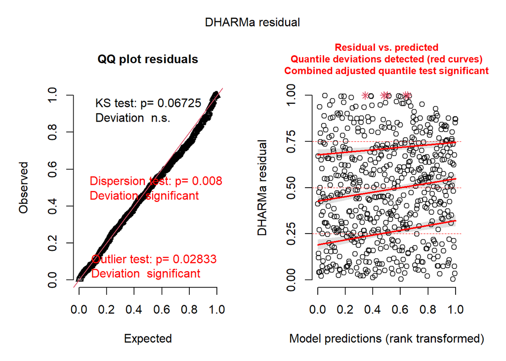

```r
DHARMa::simulateResiduals(fg.m1) %>% plot()
```

```r
check_collinearity(fg.m1)
```

```
# Check for Multicollinearity

Low Correlation

                    Term  VIF    VIF 95% CI Increased SE Tolerance
               treatment 1.01 [1.00, 55.01]         1.00      0.99
           dom_log.scale 1.42 [1.29,  1.59]         1.19      0.71
 leaf_area_mm2_log.scale 1.16 [1.09,  1.32]         1.08      0.86
               exp.round 1.40 [1.28,  1.58]         1.18      0.71
 Tolerance 95% CI
     [0.02, 1.00]
     [0.63, 0.77]
     [0.76, 0.92]
     [0.63, 0.78]
```

### 3.7.3 Plot

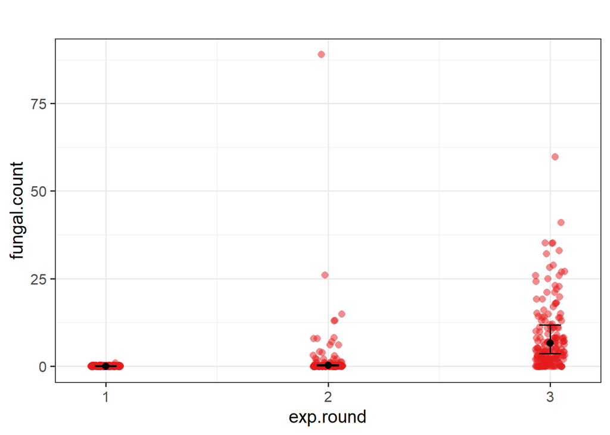

```r
plot_model(fg.m1, type = "pred", terms = c("exp.round"), show.data = TRUE, jitter = TRUE) +
  labs(title = "") +
  theme_bw(base_size = 15)
```

### 3.7.4 Misc stats

**random effect variance estimate many be unreliable**

```r
r2(fg.m1, tolerance = 10^-10)
```

```
# R2 for Mixed Models

  Conditional R2: 0.922
     Marginal R2: 0.852
```

# 4 Structural Equation Model

## 4.1 Extract mite density score

Here, I use the previous mite density GLMM we fitted to generate a predicted mite density propensity score. We are interested in some idea of mite ‘density’ affecting our response variable of interest, but we have many morphospecies of mites and it is preferable to not treat them identically. We also don’t want to include each morphospecies in the model as a predictor– that is too many variables. A solution is to generate a latent variable that takes into account that some morphospecies may be more abundant than others. We do this by taking the predicted average global mite density from the GLMM we fitted. It is not species specific because we don’t allow the prediction to include species random effects.

```r
d <- d.gathered %>%
  cbind("pred_density_score" = predict(den.m1, # Mite density model
                                       newdata = d.gathered %>%
                                         dplyr::select(all_of(names(insight::get_predictors(den.m1))),
                                                       leaf,
                                                       tree) %>%
                                         mutate(morphospecies = "hmmmm"), # Not a real species
                                       allow.new.levels = TRUE,
                                       type = "link")) %>% # Prediction on link scale is better behaved
  group_by(exp.round, tree, leaf) %>%
  summarise(pred_density_score = mean(pred_density_score)) %>% # Collapse score to each leaf
  ungroup() %>%
  right_join(d, by = c("exp.round", "leaf","tree")) %>%  # Bind to data frame for analysis
  mutate(pred_density_score = as.numeric(scale(pred_density_score)))  # Z score transform
```

## 4.2 List of models

```r
m1 <- glmmTMB(pred_density_score ~
                leaf_area_mm2_log.scale +
                treatment +
                dom_log.scale +
                exp.round +
                (1| tree),
              family = gaussian,
              control=glmmTMBControl(optimizer=optim,
                                     optArgs=list(method="BFGS")),
              data = d); summary(m1)
```

```
 Family: gaussian  ( identity )
Formula:
pred_density_score ~ leaf_area_mm2_log.scale + treatment + dom_log.scale +
    exp.round + (1 | tree)
Data: d

     AIC      BIC   logLik deviance df.resid
    10.2     45.1      2.9     -5.8      568

Random effects:

Conditional model:
 Groups   Name        Variance Std.Dev.
 tree     (Intercept) 0.03256  0.1804
 Residual             0.04639  0.2154
Number of obs: 576, groups:  tree, 65

Dispersion estimate for gaussian family (sigma^2): 0.0464

Conditional model:
                        Estimate Std. Error z value Pr(>|z|)
(Intercept)             -1.00506    0.03825  -26.28   <2e-16 ***
leaf_area_mm2_log.scale  0.01685    0.01241    1.36    0.174
treatmenttreatment      -0.09088    0.04832   -1.88    0.060 .
dom_log.scale            0.28654    0.01372   20.89   <2e-16 ***
exp.round2               1.62350    0.02754   58.95   <2e-16 ***
exp.round3               1.52673    0.03032   50.36   <2e-16 ***
---
Signif. codes:  0 '***' 0.001 '**' 0.01 '*' 0.05 '.' 0.1 ' ' 1
```

```r
m2 <- glmmTMB(PC1.scale ~
                leaf_area_mm2_log.scale +
                treatment +
                dom_log.scale +
                exp.round +
                (1| tree) +
                ar1(0 + exp.round | tree),
              family = gaussian,
              data = d); summary(m2)
```

```
 Family: gaussian  ( identity )
Formula:
PC1.scale ~ leaf_area_mm2_log.scale + treatment + dom_log.scale +
    exp.round + (1 | tree) + ar1(0 + exp.round | tree)
Data: d

     AIC      BIC   logLik deviance df.resid
  1298.6   1342.1   -639.3   1278.6      566

Random effects:

Conditional model:
 Groups   Name        Variance  Std.Dev.  Corr
 tree     (Intercept) 5.898e-09 0.0000768
 tree.1   exp.round1  9.087e-02 0.3014489 0.43 (ar1)
 Residual             4.648e-01 0.6817930
Number of obs: 576, groups:  tree, 65

Dispersion estimate for gaussian family (sigma^2): 0.465

Conditional model:
                        Estimate Std. Error z value Pr(>|z|)
(Intercept)              0.90413    0.08179  11.054   <2e-16 ***
leaf_area_mm2_log.scale -0.06562    0.03731  -1.759   0.0787 .
treatmenttreatment      -0.02731    0.08054  -0.339   0.7345
dom_log.scale           -0.03320    0.04316  -0.769   0.4418
exp.round2              -1.35293    0.09575 -14.130   <2e-16 ***
exp.round3              -1.29538    0.10735 -12.067   <2e-16 ***
---
Signif. codes:  0 '***' 0.001 '**' 0.01 '*' 0.05 '.' 0.1 ' ' 1
```

```r
m3 <- glmmTMB(PC2.scale ~
                leaf_area_mm2_log.scale +
                treatment +
                dom_log.scale +
                exp.round +
                (1| tree) +
                ar1(0 + exp.round | tree),
              family = gaussian(),
              data = d
              ); summary(m3)
```

```
 Family: gaussian  ( identity )
Formula:
PC2.scale ~ leaf_area_mm2_log.scale + treatment + dom_log.scale +
    exp.round + (1 | tree) + ar1(0 + exp.round | tree)
Data: d

     AIC      BIC   logLik deviance df.resid
  1636.7   1680.3   -808.4   1616.7      566

Random effects:

Conditional model:
 Groups   Name        Variance  Std.Dev.  Corr
 tree     (Intercept) 1.363e-08 0.0001168
 tree.1   exp.round1  9.815e-02 0.3132919 0.40 (ar1)
 Residual             8.828e-01 0.9395564
Number of obs: 576, groups:  tree, 65

Dispersion estimate for gaussian family (sigma^2): 0.883

Conditional model:
                        Estimate Std. Error z value Pr(>|z|)
(Intercept)              0.07758    0.10301   0.753   0.4514
leaf_area_mm2_log.scale  0.08649    0.04902   1.764   0.0777 .
treatmenttreatment       0.06135    0.09788   0.627   0.5308
dom_log.scale           -0.10604    0.05587  -1.898   0.0577 .
exp.round2              -0.11990    0.12483  -0.961   0.3368
exp.round3              -0.21707    0.13884  -1.563   0.1179
---
Signif. codes:  0 '***' 0.001 '**' 0.01 '*' 0.05 '.' 0.1 ' ' 1
```

```r
m4 <- glmmTMB(dom_log.scale ~
                leaf_area_mm2_log.scale +
                exp.round +
                (1| tree) +
                ar1(0 + exp.round | tree),
              family = gaussian(),
              data = d
              ); summary(m4)
```

```
 Family: gaussian  ( identity )
Formula:
dom_log.scale ~ leaf_area_mm2_log.scale + exp.round + (1 | tree) +
    ar1(0 + exp.round | tree)
Data: d

     AIC      BIC   logLik deviance df.resid
  1062.2   1097.0   -523.1   1046.2      568

Random effects:

Conditional model:
 Groups   Name        Variance  Std.Dev.  Corr
 tree     (Intercept) 1.643e-08 0.0001282
 tree.1   exp.round1  4.697e-01 0.6853163 0.37 (ar1)
 Residual             1.781e-01 0.4219892
Number of obs: 576, groups:  tree, 65

Dispersion estimate for gaussian family (sigma^2): 0.178

Conditional model:
                        Estimate Std. Error z value Pr(>|z|)
(Intercept)             -0.80070    0.09164  -8.737  < 2e-16 ***
leaf_area_mm2_log.scale  0.17132    0.03018   5.677 1.37e-08 ***
exp.round2               1.18011    0.10570  11.164  < 2e-16 ***
exp.round3               1.21570    0.12400   9.804  < 2e-16 ***
---
Signif. codes:  0 '***' 0.001 '**' 0.01 '*' 0.05 '.' 0.1 ' ' 1
```

```r
m5 <- glmmTMB(gall_mm2 ~
                PC1.scale +
                PC2.scale +
                pred_density_score +
                leaf_area_mm2_log.scale +
                treatment +
                dom_log.scale +
                exp.round +
                (1| tree) +
                ar1(0 + exp.round | tree),
              family = tweedie(),
              control=glmmTMBControl(optimizer=optim,
                                     optArgs=list(method="BFGS")),
              data = d); summary(m5)
```

```
 Family: tweedie  ( log )
Formula:
gall_mm2 ~ PC1.scale + PC2.scale + pred_density_score + leaf_area_mm2_log.scale +
    treatment + dom_log.scale + exp.round + (1 | tree) + ar1(0 +
    exp.round | tree)
Data: d

     AIC      BIC   logLik deviance df.resid
  2795.0   2856.0  -1383.5   2767.0      562

Random effects:

Conditional model:
 Groups Name        Variance Std.Dev. Corr
 tree   (Intercept) 1.66375  1.29
 tree.1 exp.round1  0.07292  0.27     -1.00 (ar1)
Number of obs: 576, groups:  tree, 65

Dispersion parameter for tweedie family (): 7.74

Conditional model:
                        Estimate Std. Error z value Pr(>|z|)
(Intercept)              0.91972    0.48927   1.880   0.0601 .
PC1.scale                0.03426    0.10273   0.334   0.7387
PC2.scale               -0.10107    0.07867  -1.285   0.1989
pred_density_score      -0.38351    0.40252  -0.953   0.3407
leaf_area_mm2_log.scale  0.21276    0.11272   1.888   0.0591 .
treatmenttreatment      -0.31028    0.36868  -0.842   0.4000
dom_log.scale            0.02763    0.15712   0.176   0.8604
exp.round2               1.19392    0.66942   1.784   0.0745 .
exp.round3               0.91477    0.63560   1.439   0.1501
---
Signif. codes:  0 '***' 0.001 '**' 0.01 '*' 0.05 '.' 0.1 ' ' 1
```

```r
m6 <- glmmTMB(herb_mm2 ~
                PC1.scale +
                PC2.scale +
                pred_density_score +
                leaf_area_mm2_log.scale +
                treatment +
                dom_log.scale +
                exp.round +
                (1| tree) +
                ar1(0 + exp.round | tree),
              family = tweedie(),
              data = d); summary(m6)
```

```
 Family: tweedie  ( log )
Formula:
herb_mm2 ~ PC1.scale + PC2.scale + pred_density_score + leaf_area_mm2_log.scale +
    treatment + dom_log.scale + exp.round + (1 | tree) + ar1(0 +
    exp.round | tree)
Data: d

     AIC      BIC   logLik deviance df.resid
   597.5    658.5   -284.8    569.5      562

Random effects:

Conditional model:
 Groups Name        Variance  Std.Dev.  Corr
 tree   (Intercept) 2.439e-07 0.0004939
 tree.1 exp.round1  3.776e+00 1.9431800 -0.32 (ar1)
Number of obs: 576, groups:  tree, 65

Dispersion parameter for tweedie family (): 27.6

Conditional model:
                        Estimate Std. Error z value Pr(>|z|)
(Intercept)              0.45494    1.27896   0.356   0.7221
PC1.scale                0.69342    0.41672   1.664   0.0961 .
PC2.scale               -0.01383    0.18397  -0.075   0.9401
pred_density_score       1.17820    1.13757   1.036   0.3003
leaf_area_mm2_log.scale -0.47351    0.24972  -1.896   0.0579 .
treatmenttreatment       1.49433    0.62922   2.375   0.0176 *
dom_log.scale            0.25440    0.48192   0.528   0.5976
exp.round2              -4.83239    2.01354  -2.400   0.0164 *
exp.round3              -3.35996    1.78088  -1.887   0.0592 .
---
Signif. codes:  0 '***' 0.001 '**' 0.01 '*' 0.05 '.' 0.1 ' ' 1
```

```r
m7 <- glmmTMB(fungal.count ~
                PC1.scale +
                PC2.scale +
                pred_density_score +
                leaf_area_mm2_log.scale +
                treatment +
                dom_log.scale +
                exp.round +
                (1| tree) +
                ar1(0 + exp.round | tree),
              family = nbinom2(),
              data = d); summary(m7)
```

```
 Family: nbinom2  ( log )
Formula:
fungal.count ~ PC1.scale + PC2.scale + pred_density_score + leaf_area_mm2_log.scale +
    treatment + dom_log.scale + exp.round + (1 | tree) + ar1(0 +
    exp.round | tree)
Data: d

     AIC      BIC   logLik deviance df.resid
  1520.9   1577.5   -747.5   1494.9      559

Random effects:

Conditional model:
 Groups Name        Variance  Std.Dev. Corr
 tree   (Intercept) 1.424e-06 0.001194
 tree.1 exp.round1  1.338e+00 1.156932 0.10 (ar1)
Number of obs: 572, groups:  tree, 65

Dispersion parameter for nbinom2 family (): 0.855

Conditional model:
                        Estimate Std. Error z value Pr(>|z|)
(Intercept)             -7.79800    1.20252  -6.485 8.89e-11 ***
PC1.scale                0.19458    0.10431   1.865 0.062131 .
PC2.scale                0.26904    0.10383   2.591 0.009564 **
pred_density_score      -1.63674    0.48661  -3.364 0.000769 ***
leaf_area_mm2_log.scale  0.07025    0.10986   0.639 0.522542
treatmenttreatment      -0.20287    0.28616  -0.709 0.478371
dom_log.scale            0.40841    0.38367   1.064 0.287106
exp.round2               7.30932    1.35547   5.392 6.95e-08 ***
exp.round3              10.57349    1.36747   7.732 1.06e-14 ***
---
Signif. codes:  0 '***' 0.001 '**' 0.01 '*' 0.05 '.' 0.1 ' ' 1
```

## 4.3 d-separation test

```r
# Using old version of piecewiseSEM that supports glmmTMB
#devtools::install_version("piecewiseSEM", version = "1.2.1", repos = "http://cran.us.r-project.org")
mod.list <- list(m1, m2, m3, m4, m5, m6, m7)
psem.out <- piecewiseSEM::sem.fit(mod.list,
                                  corr.errors = list("PC2.scale ~~ PC1.scale",
                                                     "PC1.scale ~~ pred_density_score",
                                                     "PC2.scale ~~ pred_density_score"),
                                  data = d,
                                  .progressBar = FALSE)
psem.out # Looks like there are no missing paths
```

```
$missing.paths
                     missing.path estimate std.error df crit.value p.value
1 dom_log.scale ~ treatment + ...  -0.0092    0.0589 NA    -0.1568  0.8754
2       herb_mm2 ~ gall_mm2 + ...  -0.0105    0.0146 NA    -0.7165  0.4737
3   fungal.count ~ gall_mm2 + ...   0.0041    0.0039 NA     1.0581  0.2900
4   fungal.count ~ herb_mm2 + ...   0.0201    0.0192 NA     1.0490  0.2942

$Fisher.C
  fisher.c df p.value
1     6.68  8   0.571

$AIC
     AIC    AICc  K   n
1 160.68 184.996 77 572
```

## 4.4 SEM coefficeints

**The coefficients still need to be standardized in some cases**

```r
piecewiseSEM::sem.coefs(modelList = mod.list,
          data = d)
```

```
             response               predictor    estimate  std.error p.value
1       dom_log.scale              exp.round2  1.18011499 0.10570475  0.0000
2       dom_log.scale              exp.round3  1.21570217 0.12399583  0.0000
3       dom_log.scale leaf_area_mm2_log.scale  0.17131552 0.03017623  0.0000
4        fungal.count              exp.round3 10.57349029 1.36746556  0.0000
5        fungal.count              exp.round2  7.30931808 1.35546951  0.0000
6        fungal.count      pred_density_score -1.63673762 0.48660838  0.0008
7        fungal.count               PC2.scale  0.26904073 0.10382863  0.0096
8        fungal.count               PC1.scale  0.19457829 0.10431123  0.0621
9        fungal.count           dom_log.scale  0.40841091 0.38366745  0.2871
10       fungal.count      treatmenttreatment -0.20286877 0.28616399  0.4784
11       fungal.count leaf_area_mm2_log.scale  0.07024710 0.10985852  0.5225
12           gall_mm2 leaf_area_mm2_log.scale  0.21275777 0.11271531  0.0591
13           gall_mm2              exp.round2  1.19392080 0.66942190  0.0745
14           gall_mm2              exp.round3  0.91476659 0.63559691  0.1501
15           gall_mm2               PC2.scale -0.10107427 0.07866774  0.1989
16           gall_mm2      pred_density_score -0.38351007 0.40251599  0.3407
17           gall_mm2      treatmenttreatment -0.31027804 0.36868316  0.4000
18           gall_mm2               PC1.scale  0.03426445 0.10273319  0.7387
19           gall_mm2           dom_log.scale  0.02762799 0.15712204  0.8604
20           herb_mm2              exp.round2 -4.83238709 2.01353937  0.0164
21           herb_mm2      treatmenttreatment  1.49432872 0.62921924  0.0176
22           herb_mm2 leaf_area_mm2_log.scale -0.47351140 0.24971573  0.0579
23           herb_mm2              exp.round3 -3.35995924 1.78088363  0.0592
24           herb_mm2               PC1.scale  0.69341956 0.41672428  0.0961
25           herb_mm2      pred_density_score  1.17819660 1.13757474  0.3003
26           herb_mm2           dom_log.scale  0.25440317 0.48191998  0.5976
27           herb_mm2               PC2.scale -0.01383417 0.18396527  0.9401
28          PC1.scale              exp.round2 -1.35292855 0.09574539  0.0000
29          PC1.scale              exp.round3 -1.29537756 0.10735105  0.0000
30          PC1.scale leaf_area_mm2_log.scale -0.06561600 0.03731334  0.0787
31          PC1.scale           dom_log.scale -0.03319620 0.04315764  0.4418
32          PC1.scale      treatmenttreatment -0.02730925 0.08053684  0.7345
33          PC2.scale           dom_log.scale -0.10603514 0.05586647  0.0577
34          PC2.scale leaf_area_mm2_log.scale  0.08648855 0.04902253  0.0777
35          PC2.scale              exp.round3 -0.21707420 0.13883859  0.1179
36          PC2.scale              exp.round2 -0.11989710 0.12482546  0.3368
37          PC2.scale      treatmenttreatment  0.06135254 0.09788272  0.5308
38 pred_density_score              exp.round2  1.62350419 0.02753974  0.0000
39 pred_density_score              exp.round3  1.52672677 0.03031535  0.0000
```

[output cut: 31 more lines]

```
28 ***
29 ***
30
31
32
33
34
35
36
37
38 ***
39 ***
40 ***
41
42
```

## 4.5 SEM plot

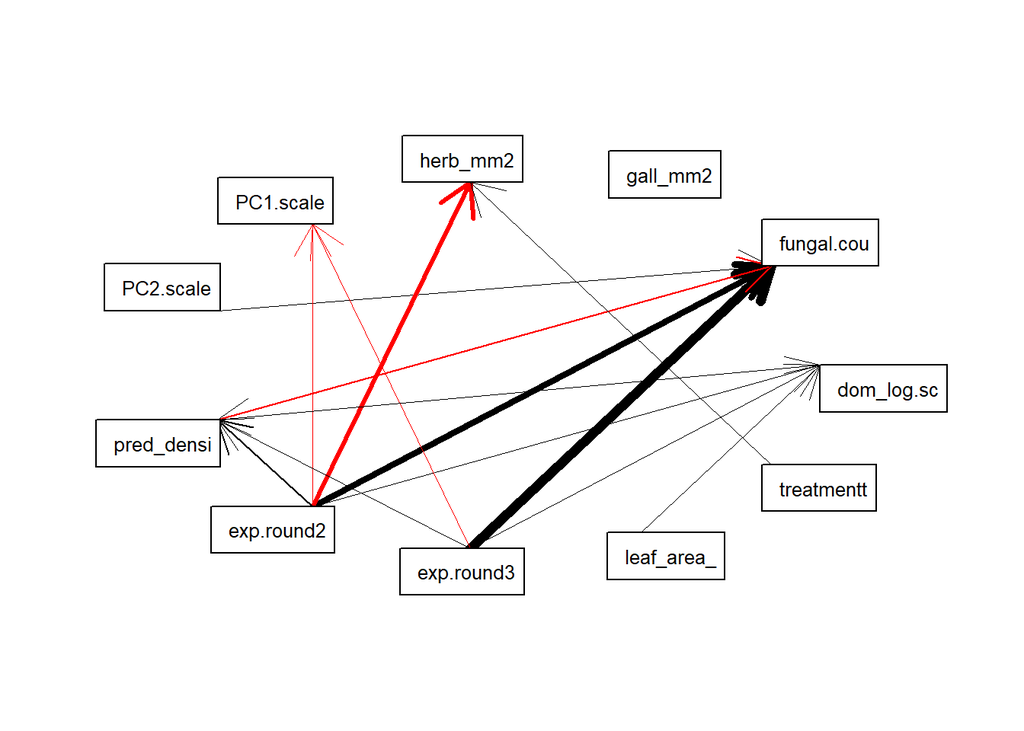

```r
piecewiseSEM::sem.plot(mod.list, data = d, show.nonsig = FALSE)
```

# 5 References

Arif, S., and A. MacNeil. 2022. Predictive models aren’t for causal inference. Ecology Letters n/a.  
/ Karban, R. 2008. Leaf Drop in Evergreen Ceanothus velutinus as a Means of Reducing Herbivory. Ecology 89:2446–2452.